```python
# DSC 530
# Week 12
# Spring 2024
# Final Programming Project
# Created By Matthew Heinen
# 3/31/24
```

# Question

```
    Can Pitcher Statcast Data Help us find trends in Tommy John Surgery occurrences. Can this data reveal patterns that can help MLB organizations predict injury potential for Major League pitchers. Additionally, are there other trends we can reveal in the data that may allow MLB General managers to make better decisions with pitcher contract selections.
```

```python
#Read in Data to DF

#Import Pandas.
import pandas as pd


tj_data = pd.read_csv('tj_combines_data.csv')

# Preview Data.
tj_data.head()
```

|  | last_name | first_name | tj_history | age | games_pitched | innings_pitched | k_percent | bb_percent | exit_velocity_avg | launch_angle_avg | ... | breaking_avg_break_x | year | breaking_avg_break_z | breaking_avg_break | offspeed_thrown | offspeed_avg_speed | offspeed_avg_spin | offspeed_avg_break_x | offspeed_avg_break_z | offspeed_avg_break |
| --- | --- | --- | --- | --- | --- | --- | --- | --- | --- | --- | --- | --- | --- | --- | --- | --- | --- | --- | --- | --- | --- |
| 0 | Aardsma | David | 0 | 34 | 33 | 30.2 | 27.1 | 10.9 | 90.1 | 18.6 | ... | -1.6 | 2015 | -39.2 | 4.4 | 6.0 | 84.3 | 1383.0 | -11.3 | -28.0 | 15.2 |
| 1 | Abad | Fernando | 0 | 32 | 48 | 43.2 | 20.3 | 7.7 | 86.8 | 11.9 | ... | -7.0 | 2017 | -55.9 | 10.6 | 22.4 | 77.8 | 1743.0 | 8.1 | -30.1 | 20.2 |
| 2 | Abad | Fernando | 0 | 31 | 57 | 46.2 | 20.7 | 11.1 | 88.4 | 11.6 | ... | -6.0 | 2016 | -56.5 | 11.4 | 16.7 | 73.9 | 1984.0 | 9.6 | -32.6 | 20.6 |
| 3 | Abad | Fernando | 0 | 30 | 62 | 47.2 | 22.0 | 9.3 | 87.1 | 13.5 | ... | -5.4 | 2015 | -53.6 | 8.6 | 13.5 | 73.2 | 1952.0 | 9.5 | -34.6 | 20.1 |
| 4 | Achter | A.J. | 0 | 28 | 27 | 37.2 | 8.8 | 7.5 | 86.6 | 12.3 | ... | 4.4 | 2016 | -34.3 | 13.1 | 42.0 | 83.5 | 1489.0 | -7.4 | -31.0 | 14.9 |

5 rows × 35 columns

First We must simplify our data to variables that we care about as well as simplify some columns.

```python
# Limit Dataset to only the variables we care to evaluate.
#Name
#Age
#tj_history
#innings_pitched
#fastball_avg_speed
#fastball_avg_spin
#breaking_avg_speed
#breaking_avg_spin
#offspeed_avg_speed
#offspeed_avg_spin

tj_data_narrow = tj_data[['last_name','first_name','tj_history','age','innings_pitched',
                   'fastball_avg_speed','fastball_avg_spin','breaking_avg_speed',
                   'breaking_avg_spin', 'offspeed_avg_speed','offspeed_avg_spin']]

#verify
tj_data_narrow.head()
```

|  | last_name | first_name | tj_history | age | innings_pitched | fastball_avg_speed | fastball_avg_spin | breaking_avg_speed | breaking_avg_spin | offspeed_avg_speed | offspeed_avg_spin |
| --- | --- | --- | --- | --- | --- | --- | --- | --- | --- | --- | --- |
| 0 | Aardsma | David | 0 | 34 | 30.2 | 92.1 | 2260 | 81.6 | 1936.0 | 84.3 | 1383.0 |
| 1 | Abad | Fernando | 0 | 32 | 43.2 | 91.5 | 2188 | 76.9 | 2450.0 | 77.8 | 1743.0 |
| 2 | Abad | Fernando | 0 | 31 | 46.2 | 91.7 | 2223 | 76.9 | 2541.0 | 73.9 | 1984.0 |
| 3 | Abad | Fernando | 0 | 30 | 47.2 | 90.3 | 2215 | 77.3 | 2139.0 | 73.2 | 1952.0 |
| 4 | Achter | A.J. | 0 | 28 | 37.2 | 91.6 | 2288 | 81.2 | 2115.0 | 83.5 | 1489.0 |

```python
# Concatinate first and last names in order to refer to pitcher by full name.

tj_data_narrow['full_name'] = tj_data_narrow["first_name"] + " " + tj_data_narrow["last_name"]

#Verify.
tj_data_narrow.head()
```

|  | last_name | first_name | tj_history | age | innings_pitched | fastball_avg_speed | fastball_avg_spin | breaking_avg_speed | breaking_avg_spin | offspeed_avg_speed | offspeed_avg_spin | full_name |
| --- | --- | --- | --- | --- | --- | --- | --- | --- | --- | --- | --- | --- |
| 0 | Aardsma | David | 0 | 34 | 30.2 | 92.1 | 2260 | 81.6 | 1936.0 | 84.3 | 1383.0 | David Aardsma |
| 1 | Abad | Fernando | 0 | 32 | 43.2 | 91.5 | 2188 | 76.9 | 2450.0 | 77.8 | 1743.0 | Fernando Abad |
| 2 | Abad | Fernando | 0 | 31 | 46.2 | 91.7 | 2223 | 76.9 | 2541.0 | 73.9 | 1984.0 | Fernando Abad |
| 3 | Abad | Fernando | 0 | 30 | 47.2 | 90.3 | 2215 | 77.3 | 2139.0 | 73.2 | 1952.0 | Fernando Abad |
| 4 | Achter | A.J. | 0 | 28 | 37.2 | 91.6 | 2288 | 81.2 | 2115.0 | 83.5 | 1489.0 | A.J. Achter |

```python
# Drop last_name and first_name

tj_data_narrow = tj_data_narrow.drop(['last_name', 'first_name'], axis=1)

#Verify.
tj_data_narrow
```

|  | tj_history | age | innings_pitched | fastball_avg_speed | fastball_avg_spin | breaking_avg_speed | breaking_avg_spin | offspeed_avg_speed | offspeed_avg_spin | full_name |
| --- | --- | --- | --- | --- | --- | --- | --- | --- | --- | --- |
| 0 | 0 | 34 | 30.2 | 92.1 | 2260 | 81.6 | 1936.0 | 84.300000 | 1383.000000 | David Aardsma |
| 1 | 0 | 32 | 43.2 | 91.5 | 2188 | 76.9 | 2450.0 | 77.800000 | 1743.000000 | Fernando Abad |
| 2 | 0 | 31 | 46.2 | 91.7 | 2223 | 76.9 | 2541.0 | 73.900000 | 1984.000000 | Fernando Abad |
| 3 | 0 | 30 | 47.2 | 90.3 | 2215 | 77.3 | 2139.0 | 73.200000 | 1952.000000 | Fernando Abad |
| 4 | 0 | 28 | 37.2 | 91.6 | 2288 | 81.2 | 2115.0 | 83.500000 | 1489.000000 | A.J. Achter |
| ... | ... | ... | ... | ... | ... | ... | ... | ... | ... | ... |
| 2547 | 0 | 32 | 131.1 | 91.1 | 2297 | 84.7 | 2366.0 | 86.700000 | 1881.000000 | Jordan Zimmermann |
| 2548 | 0 | 31 | 160.0 | 92.2 | 2339 | 84.6 | 2389.0 | 86.300000 | 2245.000000 | Jordan Zimmermann |
| 2549 | 0 | 30 | 105.1 | 92.5 | 2372 | 85.6 | 2399.0 | 87.600000 | 1791.000000 | Jordan Zimmermann |
| 2550 | 0 | 29 | 201.2 | 93.6 | 2328 | 85.3 | 2274.0 | 88.700000 | 2164.000000 | Jordan Zimmermann |
| 2551 | 0 | 27 | 40.2 | 94.5 | 2038 | 80.6 | 2532.0 | 85.036787 | 1744.228659 | Tony Zych |

2552 rows × 10 columns

```python
# Summarize data so there is only one row per player.
# For the purpose of this experiment we will take the mazimum numbers from each player across their multiple seasons.
# This decesion is made because we then know we will be pulling a players best numbers or potential for a season.

tj_data_summary = tj_data_narrow.groupby(['full_name']).max()

tj_data_summary
```

| full_name | tj_history | age | innings_pitched | fastball_avg_speed | fastball_avg_spin | breaking_avg_speed | breaking_avg_spin | offspeed_avg_speed | offspeed_avg_spin |
| --- | --- | --- | --- | --- | --- | --- | --- | --- | --- |
| A.J. Achter | 0 | 28 | 37.2 | 91.6 | 2288 | 81.2 | 2115.00000 | 83.500000 | 1489.000000 |
| A.J. Burnett | 0 | 38 | 164.0 | 91.6 | 2009 | 82.3 | 2023.00000 | 86.300000 | 1678.000000 |
| A.J. Cole | 0 | 27 | 52.0 | 94.4 | 2406 | 83.1 | 2371.00000 | 86.500000 | 2189.000000 |
| A.J. Griffin | 0 | 29 | 119.0 | 88.2 | 2306 | 74.9 | 2587.00000 | 81.400000 | 1783.000000 |
| A.J. Minter | 0 | 26 | 61.1 | 94.1 | 2472 | 86.3 | 2350.47096 | 86.200000 | 1767.000000 |
| ... | ... | ... | ... | ... | ... | ... | ... | ... | ... |
| Zack Britton | 0 | 32 | 67.0 | 96.9 | 2099 | 84.0 | 2641.00000 | 85.036787 | 1744.228659 |
| Zack Godley | 0 | 29 | 178.1 | 91.5 | 2276 | 83.1 | 2223.00000 | 83.800000 | 1717.000000 |
| Zack Greinke | 0 | 36 | 222.2 | 92.3 | 2382 | 83.2 | 2594.00000 | 88.700000 | 1821.000000 |
| Zack Littell | 0 | 24 | 37.0 | 93.8 | 2076 | 86.2 | 2139.00000 | 86.900000 | 1812.000000 |
| Zack Wheeler | 0 | 29 | 195.1 | 96.7 | 2301 | 87.6 | 2496.00000 | 89.100000 | 1805.000000 |

995 rows × 9 columns

### Describe what the variables mean in the dataset (Chapter 1).

```
- full_name is the name of the pitcher.
- tj_history is a binary intiger of if they have undergone Tommy John surgery or not. The code 1 indicates Tommy John surgery.
- age is the intiger age of the pitcher
- innings_pitched is the maximum number of innings a pitcher has thrown in a season.
- fastball_avg_speed is the average fastball speed in MPH from the pitchers best season.
- fastball_average_spin is the average fastball spin in RPM from the pitchers best season.
- breaking_avg_speed is the average breaking ball speed in MPH from the pitchers best season. Examples include Curveball, Slider, Slurve, and Screwballs.
- breaking_avg_spin is the average breaking ball spin in RPM from the pitchers best season. Examples include Curveball, Slider, Slurve, and Screwballs.
- offspeed_avg_speed is the average offspeed pitch speed in MPH from the pitchers best season. Examples include splitters changeups and knuckleballs.
- offspees_avg_spin is the average offspeed pitch spin in RPM from the pitchers best season. Examples include splitters changeups and knuckleballs.
```

```python
# Data Exploration Histograms.
# Include Histogram for every variable
```

### Include a histogram of each variable – in your summary and analysis, identify any outliers and explain the reasoning for them being outliers and how you believe they should be handled (Chapter 2).

### Include the other descriptive characteristics about the variables: Mean, Mode, Spread, and Tails (Chapter 2).

```python
# Download Thinkstats2.
from os.path import basename, exists


def download(url):
    filename = basename(url)
    if not exists(filename):
        from urllib.request import urlretrieve

        local, _ = urlretrieve(url, filename)
        print("Downloaded " + local)


download("https://github.com/AllenDowney/ThinkStats2/raw/master/code/thinkstats2.py")
download("https://github.com/AllenDowney/ThinkStats2/raw/master/code/thinkplot.py")
```

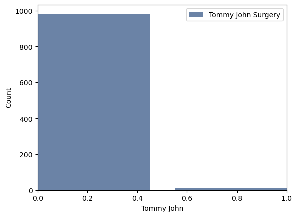

```python
# tj_history

# import thinkstats2 package
import thinkstats2

# import thinkplot.
import thinkplot

# Build Histogram
tj_hist = thinkstats2.Hist(tj_data_summary.tj_history, label='Tommy John Surgery')
thinkplot.Hist(tj_hist)
thinkplot.Config(xlabel='Tommy John', ylabel='Count', xlim=[0,1], xsacle=1.0)
```

```
    For the histograms below I need to evaluate those with and without TJ surgery. In order to do that I need to create two subsets of data with and without Tommy John.
```

```python
#Create dataset with TJ

had_tj = tj_data_summary[tj_data_summary.tj_history == 1]

# Create dataset without TJ.
no_tj = tj_data_summary[tj_data_summary.tj_history == 0]
```

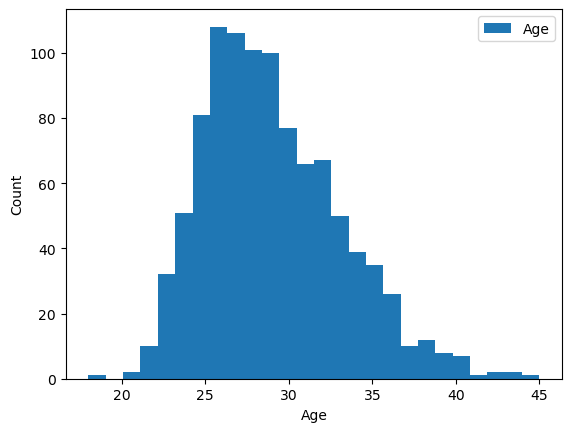

```
Mean:  29.12060301507538
Mode:  0    26
Name: age, dtype: int64
Variance:  15.659484545463703
Standard Deviation :  3.957206659433356
```

```python
# age
# Create histogram buing matplotlib and 30 binsto improve readability.
import numpy as np
import matplotlib.pyplot as plt


x = tj_data_summary.age
# Use 27 bins one for every age.
bins = np.linspace(18, 45, 27)

plt.hist([x], bins, label=['Age'])
plt.legend(loc='upper right')
plt.xlabel("Age")
plt.ylabel("Count")
plt.show()

#Print Descriptive Stats.
# mean
print('Mean: ', tj_data_summary.age.mean())
# mode
print('Mode: ', tj_data_summary.age.mode())
# variance
print('Variance: ', tj_data_summary.age.var())
# standard deviation
print('Standard Deviation : ', tj_data_summary.age.std())
```

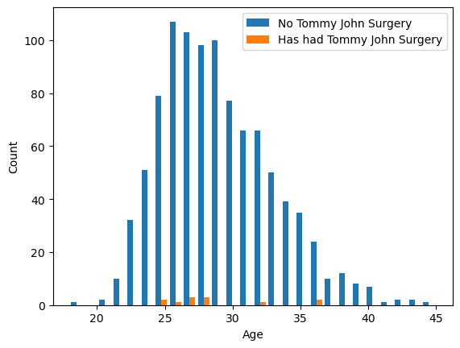

```
No TJ Mean:  29.125127161749745
Had TJ Mean:  28.75
T-statistic value:  0.3262498555948182
P-Value:  0.7443040679683057
```

```python
# age by tj

x = no_tj.age
y = had_tj.age
# Use 27 bins one for every age.
bins = np.linspace(18, 45, 27)

plt.hist([x,y], bins, label=['No Tommy John Surgery','Has had Tommy John Surgery'])
plt.legend(loc='upper right')
plt.xlabel("Age")
plt.ylabel("Count")
plt.show()


#Print Means
print("No TJ Mean: ", x.mean())
print("Had TJ Mean: ",y.mean())

# Import the library to perform T-test.
import scipy.stats as stats

# Perform the two sample t-test to test difference of means.

t_stat, p_value = stats.ttest_ind(x, y)
print("T-statistic value: ", t_stat)
print("P-Value: ", p_value)
```

```
    When evaluating the distribution of the age variable we see that it is quite skewed to the right, this is what we would expect as players can only ever the league at 18 and play as long as they are effective. We do not see any outliers and there is no apparent difference of means in age of players who have and have not had Tommy John surgery.
```

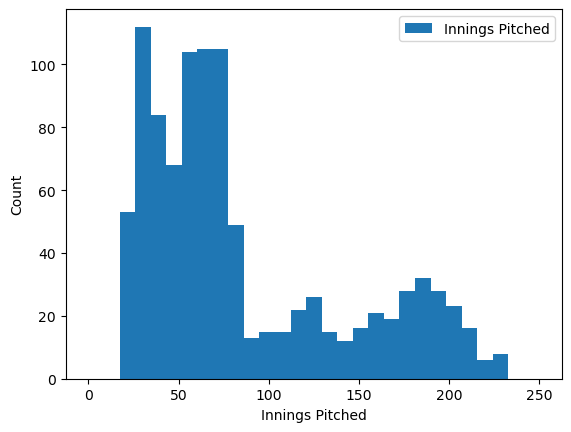

```
Mean:  86.07969849246233
Mode:  0    65.1
Name: innings_pitched, dtype: float64
Min:  18.1
Max:  232.2
Variance:  3192.987152826509
Standard Deviation :  56.506523099784765
```

```python
# Innings Pitched
x = tj_data_summary.innings_pitched
bins = np.linspace(0, 250, 30)

plt.hist([x], bins, label=['Innings Pitched'])
plt.legend(loc='upper right')
plt.xlabel("Innings Pitched")
plt.ylabel("Count")
plt.show()

#Print Descriptive Stats.
# mean
print('Mean: ', tj_data_summary.innings_pitched.mean())
# mode
print('Mode: ', tj_data_summary.innings_pitched.mode())
# min
print('Min: ', tj_data_summary.innings_pitched.min())
# max
print('Max: ', tj_data_summary.innings_pitched.max())
# variance
print('Variance: ', tj_data_summary.innings_pitched.var())
# standard deviation
print('Standard Deviation : ', tj_data_summary.innings_pitched.std())
```

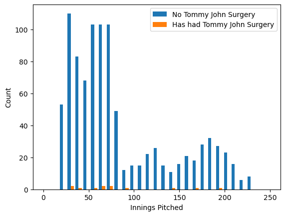

```
No TJ Mean:  86.09664292980672
Had TJ Mean:  84.69166666666668
T-statistic value:  0.08556758523438178
P-Value:  0.9318274161362862
```

```python
# innings pitched by TJ

x = no_tj.innings_pitched
y = had_tj.innings_pitched
bins = np.linspace(0, 250, 30)

plt.hist([x,y], bins, label=['No Tommy John Surgery','Has had Tommy John Surgery'])
plt.legend(loc='upper right')
plt.xlabel("Innings Pitched")
plt.ylabel("Count")
plt.show()

#Print Means
print("No TJ Mean: ", x.mean())
print("Had TJ Mean: ",y.mean())

# Perform the two sample t-test to test difference of means.

t_stat, p_value = stats.ttest_ind(x, y)
print("T-statistic value: ", t_stat)
print("P-Value: ", p_value)
```

```
    When evaluating innings pitched, we see a pretty abnormal distribution. This can be explained by the difference between starting and relieving pitchers who play different roles on a team. We see this phenomenon in the large statistics for standard deviation (56 innings) and variance. Again, here we do not see any outliers as both the minimum and maximum innings pitched are reasonable and fair sample size to judge a pitcher's performance. There is no statistical evidence to support that pitchers who have had Tommy John throw less innings than those who have not.
```

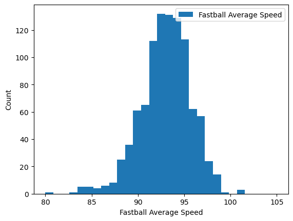

```
Mean:  93.02010050251256
Mode:  0    93.7
Name: fastball_avg_speed, dtype: float64
Min:  80.3
Max:  101.1
Variance:  7.2648873138327605
Standard Deviation :  2.6953454906250442
```

```python
# fastball_average_speed

x = tj_data_summary.fastball_avg_speed
bins = np.linspace(80, 105, 30)

plt.hist([x], bins, label=['Fastball Average Speed'])
plt.legend(loc='upper right')
plt.xlabel("Fastball Average Speed")
plt.ylabel("Count")
plt.show()

#Print Descriptive Stats.
# mean
print('Mean: ', tj_data_summary.fastball_avg_speed.mean())
# mode
print('Mode: ', tj_data_summary.fastball_avg_speed.mode())
# min
print('Min: ', tj_data_summary.fastball_avg_speed.min())
# max
print('Max: ', tj_data_summary.fastball_avg_speed.max())
# variance
print('Variance: ', tj_data_summary.fastball_avg_speed.var())
# standard deviation
print('Standard Deviation : ', tj_data_summary.fastball_avg_speed.std())
```

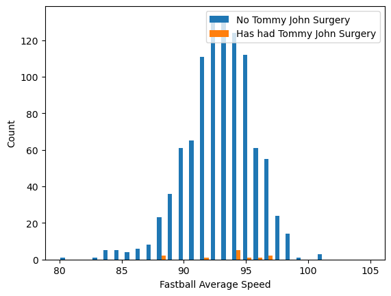

```
No TJ Mean:  93.01057985757883
Had TJ Mean:  93.80000000000001
T-statistic value:  -1.0084475385169134
P-Value:  0.31348532479275476
```

```python
# fastball_avg_speed by tj

x = no_tj.fastball_avg_speed
y = had_tj.fastball_avg_speed
bins = np.linspace(80, 105, 30)

plt.hist([x,y], bins, label=['No Tommy John Surgery','Has had Tommy John Surgery'])
plt.legend(loc='upper right')
plt.xlabel("Fastball Average Speed")
plt.ylabel("Count")
plt.show()

#Print Means
print("No TJ Mean: ", x.mean())
print("Had TJ Mean: ",y.mean())

# Perform the two sample t-test to test difference of means.

t_stat, p_value = stats.ttest_ind(x, y)
print("T-statistic value: ", t_stat)
print("P-Value: ", p_value)
```

```
    When evaluating the distribution of fastball average speed, we see that it appears to be slightly skewed to the left. This is due to outliers we see some pitchers listed as throwing well below 85 miles per hour. It is likely that any pitcher throwing this slow is not an effective pitcher and is not relevant to the purpose of this experiment. Additionally, there appears to be no statistical difference between the means of those who have and have not had Tommy John surgery.
```

```python
# Remove outliers
# Remove any pitcher with fastball velocity below 82 mph.
tj_data_summary = tj_data_summary[tj_data_summary.fastball_avg_speed >82]

# apply to had_tj and no_tj.
#Create dataset with TJ

had_tj = tj_data_summary[tj_data_summary.tj_history == 1]

# Create dataset without TJ.
no_tj = tj_data_summary[tj_data_summary.tj_history == 0]
```

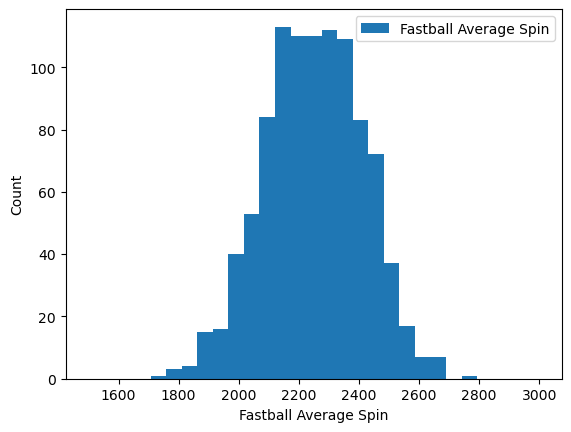

```
Mean:  2250.2505030181087
Mode:  0    2162
Name: fastball_avg_spin, dtype: int64
Min:  1753
Max:  2748
Variance:  26244.18995442949
Standard Deviation :  162.0005862780425
```

```python
# Fastball_average_spin

x = tj_data_summary.fastball_avg_spin
bins = np.linspace(1500, 3000, 30)

plt.hist([x], bins, label=['Fastball Average Spin'])
plt.legend(loc='upper right')
plt.xlabel("Fastball Average Spin")
plt.ylabel("Count")
plt.show()

#Print Descriptive Stats.
# mean
print('Mean: ', tj_data_summary.fastball_avg_spin.mean())
# mode
print('Mode: ', tj_data_summary.fastball_avg_spin.mode())
# min
print('Min: ', tj_data_summary.fastball_avg_spin.min())
# max
print('Max: ', tj_data_summary.fastball_avg_spin.max())
# variance
print('Variance: ', tj_data_summary.fastball_avg_spin.var())
# standard deviation
print('Standard Deviation : ', tj_data_summary.fastball_avg_spin.std())
```

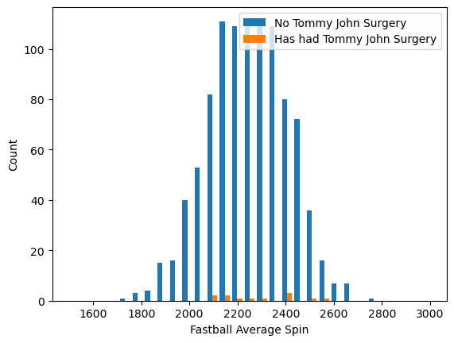

```
No TJ Mean:  2249.7270875763747
Had TJ Mean:  2293.0833333333335
T-statistic value:  -0.9214149111514333
P-Value:  0.3570578732362676
```

```python
# fastball_avg_spin by tj

x = no_tj.fastball_avg_spin
y = had_tj.fastball_avg_spin
bins = np.linspace(1500, 3000, 30)

plt.hist([x,y], bins, label=['No Tommy John Surgery','Has had Tommy John Surgery'])
plt.legend(loc='upper right')
plt.xlabel("Fastball Average Spin")
plt.ylabel("Count")
plt.show()

#Print Means
print("No TJ Mean: ", x.mean())
print("Had TJ Mean: ",y.mean())

# Perform the two sample t-test to test difference of means.

t_stat, p_value = stats.ttest_ind(x, y)
print("T-statistic value: ", t_stat)
print("P-Value: ", p_value)
```

```
    The distribution of fastball average spin appears to be normally distributed. There is little evidence that pitchers who have had Tommy John throw fastballs with more spin
```

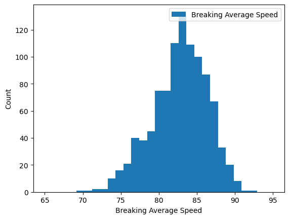

```
Mean:  82.75570618495645
Mode:  0    81.6
Name: breaking_avg_speed, dtype: float64
Min:  70.1
Max:  92.4
Variance:  12.924293435055962
Standard Deviation :  3.5950373343062743
```

```python
# breaking_avg_speed

x = tj_data_summary.breaking_avg_speed
bins = np.linspace(65, 95, 30)

plt.hist([x], bins, label=['Breaking Average Speed'])
plt.legend(loc='upper right')
plt.xlabel("Breaking Average Speed")
plt.ylabel("Count")
plt.show()

#Print Descriptive Stats.
# mean
print('Mean: ', tj_data_summary.breaking_avg_speed.mean())
# mode
print('Mode: ', tj_data_summary.breaking_avg_speed.mode())
# min
print('Min: ', tj_data_summary.breaking_avg_speed.min())
# max
print('Max: ', tj_data_summary.breaking_avg_speed.max())
# variance
print('Variance: ', tj_data_summary.breaking_avg_speed.var())
# standard deviation
print('Standard Deviation : ', tj_data_summary.breaking_avg_speed.std())
```

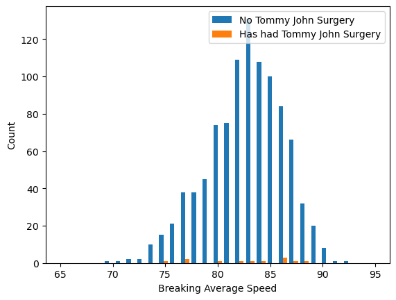

```
No TJ Mean:  82.75709974322474
Had TJ Mean:  82.64166666666667
T-statistic value:  0.11050041911422316
P-Value:  0.9120348684720534
```

```python
# breaking_avg_speed by tj

x = no_tj.breaking_avg_speed
y = had_tj.breaking_avg_speed
bins = np.linspace(65, 95, 30)

plt.hist([x,y], bins, label=['No Tommy John Surgery','Has had Tommy John Surgery'])
plt.legend(loc='upper right')
plt.xlabel("Breaking Average Speed")
plt.ylabel("Count")
plt.show()

#Print Means
print("No TJ Mean: ", x.mean())
print("Had TJ Mean: ",y.mean())

# Perform the two sample t-test to test difference of means.

t_stat, p_value = stats.ttest_ind(x, y)
print("T-statistic value: ", t_stat)
print("P-Value: ", p_value)
```

[output not shown]

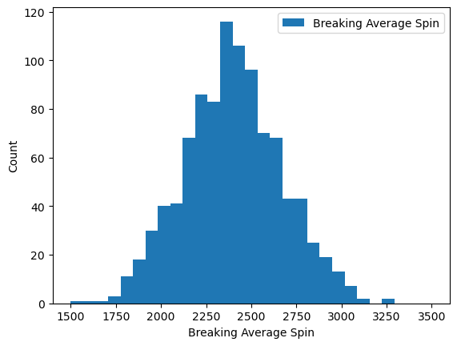

```
Mean:  2398.7718698600133
Mode:  0    2350.47096
Name: breaking_avg_spin, dtype: float64
Min:  1319.0
Max:  3270.0
Variance:  73884.49937394404
Standard Deviation :  271.8170328988675
```

```python
# breaking_avg_spin

x = tj_data_summary.breaking_avg_spin
bins = np.linspace(1500, 3500, 30)

plt.hist([x], bins, label=['Breaking Average Spin'])
plt.legend(loc='upper right')
plt.xlabel("Breaking Average Spin")
plt.ylabel("Count")
plt.show()

#Print Descriptive Stats.
# mean
print('Mean: ', tj_data_summary.breaking_avg_spin.mean())
# mode
print('Mode: ', tj_data_summary.breaking_avg_spin.mode())
# min
print('Min: ', tj_data_summary.breaking_avg_spin.min())
# max
print('Max: ', tj_data_summary.breaking_avg_spin.max())
# variance
print('Variance: ', tj_data_summary.breaking_avg_spin.var())
# standard deviation
print('Standard Deviation : ', tj_data_summary.breaking_avg_spin.std())
```

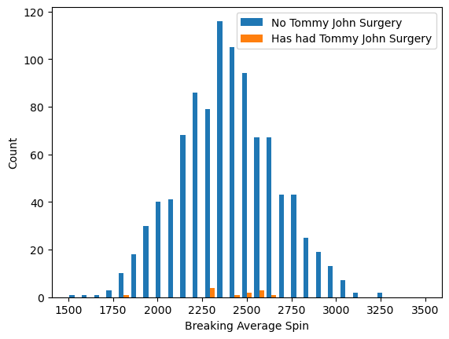

```
No TJ Mean:  2398.6509558460825
Had TJ Mean:  2408.6666666666665
T-statistic value:  -0.12680693799154277
P-Value:  0.8991189019257828
```

```python
# breaking_avg_spin by tj

x = no_tj.breaking_avg_spin
y = had_tj.breaking_avg_spin
bins = np.linspace(1500, 3500, 30)

plt.hist([x,y], bins, label=['No Tommy John Surgery','Has had Tommy John Surgery'])
plt.legend(loc='upper right')
plt.xlabel("Breaking Average Spin")
plt.ylabel("Count")
plt.show()

#Print Means
print("No TJ Mean: ", x.mean())
print("Had TJ Mean: ",y.mean())

# Perform the two sample t-test to test difference of means.

t_stat, p_value = stats.ttest_ind(x, y)
print("T-statistic value: ", t_stat)
print("P-Value: ", p_value)
```

```
    The distribution of breaking ball average spin appears to be normally distributed. There is a lot of spread in this variable as seen by the large standard deviation and variance. This phenomenon is likely explained by the different types of pitches in the breaking category. There is little evidence that pitchers who have had Tommy John throw breaking balls with more spin.
```

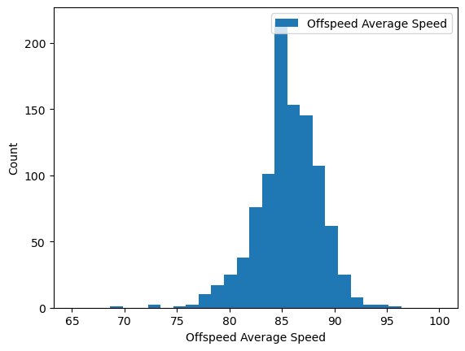

```
Mean:  85.62365849428308
Mode:  0    85.036787
Name: offspeed_avg_speed, dtype: float64
Min:  68.8
Max:  95.2
Variance:  8.867054130851246
Standard Deviation :  2.9777599182693097
```

```python
# offspeed_avg_speed

x = tj_data_summary.offspeed_avg_speed
bins = np.linspace(65, 100, 30)

plt.hist([x], bins, label=['Offspeed Average Speed'])
plt.legend(loc='upper right')
plt.xlabel("Offspeed Average Speed")
plt.ylabel("Count")
plt.show()

#Print Descriptive Stats.
# mean
print('Mean: ', tj_data_summary.offspeed_avg_speed.mean())
# mode
print('Mode: ', tj_data_summary.offspeed_avg_speed.mode())
# min
print('Min: ', tj_data_summary.offspeed_avg_speed.min())
# max
print('Max: ', tj_data_summary.offspeed_avg_speed.max())
# variance
print('Variance: ', tj_data_summary.offspeed_avg_speed.var())
# standard deviation
print('Standard Deviation : ', tj_data_summary.offspeed_avg_speed.std())
```

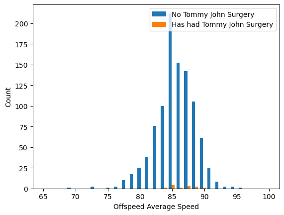

```
No TJ Mean:  85.61144905202661
Had TJ Mean:  86.62279785227109
T-statistic value:  -1.1696203600757151
P-Value:  0.24243472406693262
```

```python
# offspeed_avg_speed by tj

x = no_tj.offspeed_avg_speed
y = had_tj.offspeed_avg_speed
bins = np.linspace(65, 100, 30)

plt.hist([x,y], bins, label=['No Tommy John Surgery','Has had Tommy John Surgery'])
plt.legend(loc='upper right')
plt.xlabel("Offspeed Average Speed")
plt.ylabel("Count")
plt.show()

#Print Means
print("No TJ Mean: ", x.mean())
print("Had TJ Mean: ",y.mean())

# Perform the two sample t-test to test difference of means.

t_stat, p_value = stats.ttest_ind(x, y)
print("T-statistic value: ", t_stat)
print("P-Value: ", p_value)
```

[output not shown]

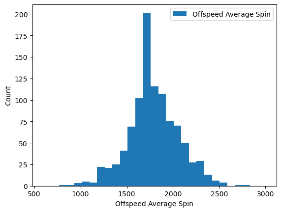

```
Mean:  1790.246515679443
Mode:  0    1744.228659
Name: offspeed_avg_spin, dtype: float64
Min:  776.0
Max:  2794.0
Variance:  73189.47335244779
Standard Deviation :  270.5355306654706
```

```python
# offspead_avg_spin

x = tj_data_summary.offspeed_avg_spin
bins = np.linspace(600, 3000, 30)

plt.hist([x], bins, label=['Offspeed Average Spin'])
plt.legend(loc='upper right')
plt.xlabel("Offspeed Average Spin")
plt.ylabel("Count")
plt.show()

#Print Descriptive Stats.
# mean
print('Mean: ', tj_data_summary.offspeed_avg_spin.mean())
# mode
print('Mode: ', tj_data_summary.offspeed_avg_spin.mode())
# min
print('Min: ', tj_data_summary.offspeed_avg_spin.min())
# max
print('Max: ', tj_data_summary.offspeed_avg_spin.max())
# variance
print('Variance: ', tj_data_summary.offspeed_avg_spin.var())
# standard deviation
print('Standard Deviation : ', tj_data_summary.offspeed_avg_spin.std())
```

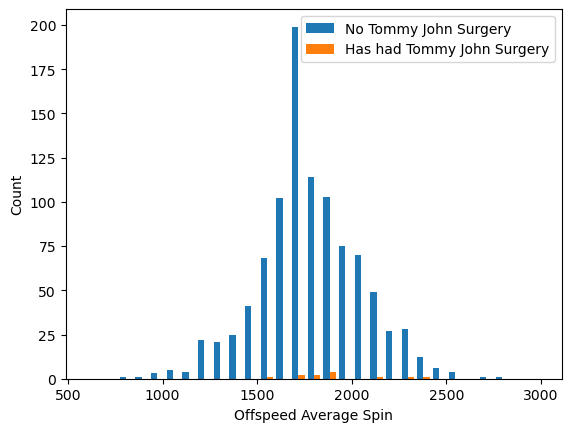

```
No TJ Mean:  1788.7900284387267
Had TJ Mean:  1909.435721544716
T-statistic value:  -1.536519512704618
P-Value:  0.12472989189455345
```

```python
# offspeed_avg_spin by tj

x = no_tj.offspeed_avg_spin
y = had_tj.offspeed_avg_spin
bins = np.linspace(600, 3000, 30)

plt.hist([x,y], bins, label=['No Tommy John Surgery','Has had Tommy John Surgery'])
plt.legend(loc='upper right')
plt.xlabel("Offspeed Average Spin")
plt.ylabel("Count")
plt.show()


#Print Means
print("No TJ Mean: ", x.mean())
print("Had TJ Mean: ",y.mean())

# Perform the two sample t-test to test difference of means.

t_stat, p_value = stats.ttest_ind(x, y)
print("T-statistic value: ", t_stat)
print("P-Value: ", p_value)
```

```
    Offspeed average spin appeart to be relatively normally distributed with no outliers. There is no evidence of outliers and a great deal of spread, likely again explained by pitch mix. This most interesting finding from this variable is that this is the strongest evidence we have seen in a difference of means between those who have and have not had Tommy John surgery. There is some evidence that pitchers who have had Tommy John surgery throw with more offspeed spin (85% confidence interval).
```

### Using pg. 29 of your text as an example, compare two scenarios in your data using a PMF. Reminder, this isn’t comparing two variables against each other – it is the same variable, but a different scenario. Almost like a filter. The example in the book is first babies compared to all other babies, it is still the same variable, but breaking the data out based on criteria we are exploring (Chapter 3).

```python
# Evaluate fastball velocity. between thos with and without TJ via PMF.
```

```python
# round fastball velocity to nearest integer.

no_tj_fb_round = no_tj.round({'fastball_avg_speed': 0})
had_tj_fb_round = had_tj.round({'fastball_avg_speed': 0})
```

```python
# Make Fastball Velocity PMF's

fastball_pmf_no_tj = thinkstats2.Pmf(no_tj_fb_round.fastball_avg_speed, label="No Tommy John")
fastball_pmf_had_tj = thinkstats2.Pmf(had_tj_fb_round.fastball_avg_speed, label = "Had Tommy John")
```

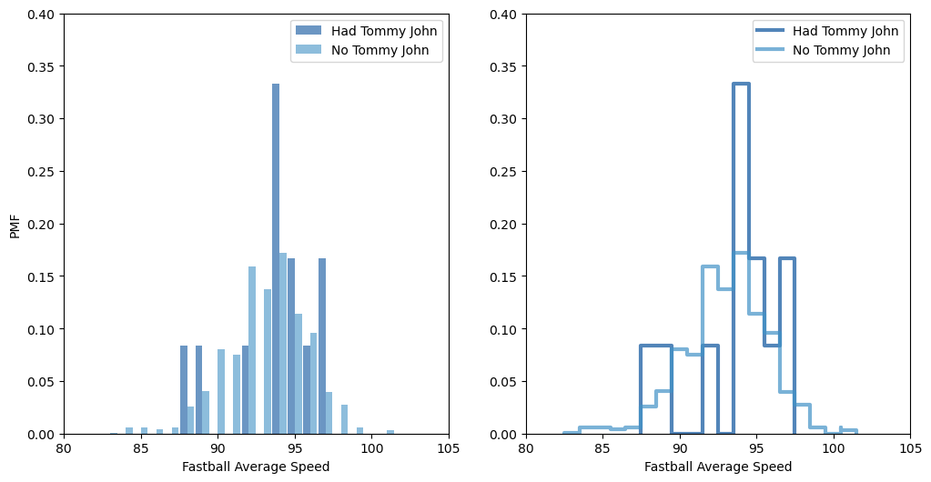

```python
# Plot Fastball PMF's.

width = 0.45
axis = [80, 105, 0, 0.4]
thinkplot.PrePlot(2, cols=2)
thinkplot.Hist(fastball_pmf_had_tj, align="right", width=width)
thinkplot.Hist(fastball_pmf_no_tj, align="left", width=width)
thinkplot.Config(xlabel="Fastball Average Speed", ylabel="PMF", axis=axis)

thinkplot.PrePlot(2)
thinkplot.SubPlot(2)
thinkplot.Pmfs([fastball_pmf_had_tj, fastball_pmf_no_tj])
thinkplot.Config(xlabel="Fastball Average Speed", axis=axis)
```

```
    The PMF above allows us to evaluate the relative distribution of fastball average speed between those who have and have not had Tommy John surgery. From both plots (bar graph and step plot), we see there seems to be little difference in the distribution of fastball speed between the two groups. Thus, providing a visual confirmation to the t-test performed above.
```

```python
# Now evaluate offspeed average spin with pmf's
```

```python
# round offspeed spin to nearest hundred rmp.

no_tj_round = no_tj.round({'offspeed_avg_spin': -2})
had_tj_round = had_tj.round({'offspeed_avg_spin': -2})
```

```python
# Make Offspeed Spin PMF's

offspeed_pmf_no_tj = thinkstats2.Pmf(no_tj_round.offspeed_avg_spin, label="No Tommy John")
offspeed_pmf_had_tj = thinkstats2.Pmf(had_tj_round.offspeed_avg_spin, label = "Had Tommy John")
```

[figure not shown]

```python
# Plot offspeed PMF's.

width = 0.45
axis = [600, 3000, 0, 0.4]
thinkplot.PrePlot(2, cols=2)
thinkplot.Hist(offspeed_pmf_had_tj, align="right", width=width)
thinkplot.Hist(offspeed_pmf_no_tj, align="left", width=width)
thinkplot.Config(xlabel="Offspeed Average Spin", ylabel="PMF", axis=axis)

thinkplot.PrePlot(2)
thinkplot.SubPlot(2)
thinkplot.Pmfs([offspeed_pmf_had_tj, offspeed_pmf_no_tj])
thinkplot.Config(xlabel="Offspeed Average Spin", axis=axis)
```

[output not shown]

### Create 1 CDF with one of your variables, using page 41-44 as your guide, what does this tell you about your variable and how does it address the question you are trying to answer (Chapter 4).

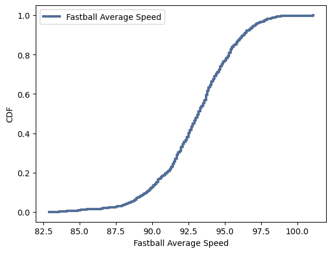

```python
# Create a CDF of average fastball speed.

# fastball speed cdf.
fb_speed_cdf = thinkstats2.Cdf(tj_data_summary.fastball_avg_speed, label= 'Fastball Average Speed')

#plot
thinkplot.Cdf(fb_speed_cdf)
thinkplot.Show(xlabel = 'Fastball Average Speed', ylabel = 'CDF')
```

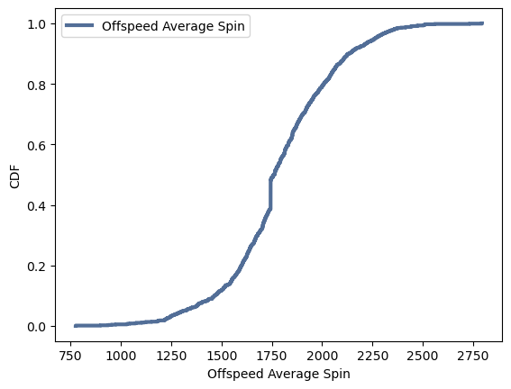

```python
# Create CDF of Offspeed Average Spin

# Offspeed Spin CDF.
offspeed_spin_cdf = thinkstats2.Cdf(tj_data_summary.offspeed_avg_spin, label= 'Offspeed Average Spin')

#plot
thinkplot.Cdf(offspeed_spin_cdf)
thinkplot.Show(xlabel = 'Offspeed Average Spin', ylabel = 'CDF')
```

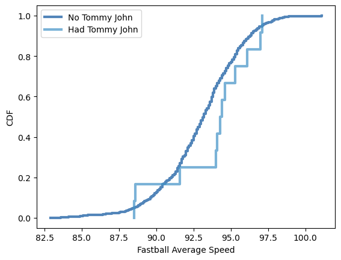

```python
#Create CDF of Fastball Average Speed Comparing those with and without Tommy John surgery.

#Build CDF's
fb_cdf_no_tj = thinkstats2.Cdf(no_tj.fastball_avg_speed, label = 'No Tommy John')
fb_cdf_had_tj = thinkstats2.Cdf(had_tj.fastball_avg_speed, label = 'Had Tommy John')

#Plot
thinkplot.PrePlot(2)
thinkplot.Cdfs([fb_cdf_no_tj, fb_cdf_had_tj])
thinkplot.Show(xlabel='Fastball Average Speed' , ylabel='CDF')
```

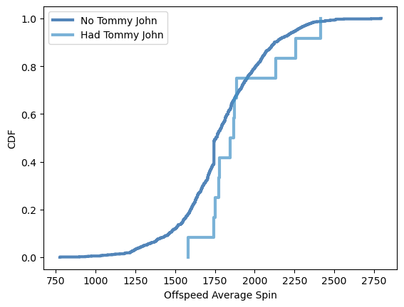

```python
# Create CDF of Offspeed Average Spin comparing those with and without Tommy John surgery.

#Build CDF's
ofs_cdf_no_tj = thinkstats2.Cdf(no_tj.offspeed_avg_spin, label = 'No Tommy John')
ofs_cdf_had_tj = thinkstats2.Cdf(had_tj.offspeed_avg_spin, label = 'Had Tommy John')

#Plot
thinkplot.PrePlot(2)
thinkplot.Cdfs([ofs_cdf_no_tj, ofs_cdf_had_tj])
thinkplot.Show(xlabel='Offspeed Average Spin' , ylabel='CDF')
```

## Analysis

[output not shown]

### Plot 1 analytical distribution and provide your analysis on how it applies to the dataset you have chosen (Chapter 5)

```
Mean, Var 1790.695734206318 62571.732597706374
Sigma 250.14342405449392
```

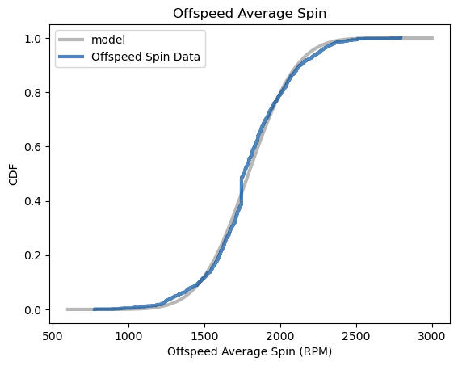

```python
# evaluate the normal distribution of offspeed average spin.

of_spin = tj_data_summary.offspeed_avg_spin

# estimate parameters: trimming outliers yields a better fit
mu, var = thinkstats2.TrimmedMeanVar(of_spin, p=0.01)
print("Mean, Var", mu, var)

# plot the model
sigma = np.sqrt(var)
print("Sigma", sigma)
xs, ps = thinkstats2.RenderNormalCdf(mu, sigma, low=600, high=3000)

thinkplot.Plot(xs, ps, label="model", color="0.6")

# plot the data
of_spin_cdf = thinkstats2.Cdf(of_spin, label="Offspeed Spin Data")

thinkplot.PrePlot(1)
thinkplot.Cdf(of_spin_cdf)
thinkplot.Config(title="Offspeed Average Spin", xlabel="Offspeed Average Spin (RPM)", ylabel="CDF")
```

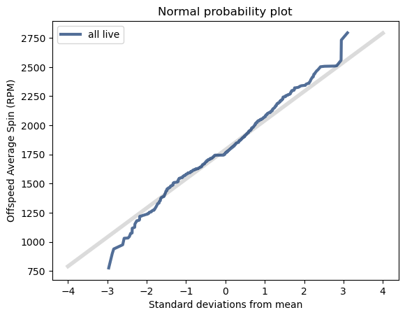

```python
mean, var = thinkstats2.TrimmedMeanVar(of_spin, p=0.01)
std = np.sqrt(var)

xs = [-4, 4]
fxs, fys = thinkstats2.FitLine(xs, mean, std)
thinkplot.Plot(fxs, fys, linewidth=4, color="0.8")

xs, ys = thinkstats2.NormalProbability(of_spin)
thinkplot.Plot(xs, ys, label="all live")

thinkplot.Config(
    title="Normal probability plot",
    xlabel="Standard deviations from mean",
    ylabel="Offspeed Average Spin (RPM)",
)
```

```
    Here we can see that the data fits the normal model very well except for the tails. If we remember there is an argument to be made that those who have had Tommy John surgery generate more offspeed spin. Let's see if removing those with Tommy John surgery improves the normality of the data.
```

```python
# Create Variable for Offspeed spin of those who have not had Tommy John surgery.

of_spin_no_tj = no_tj.offspeed_avg_spin
```

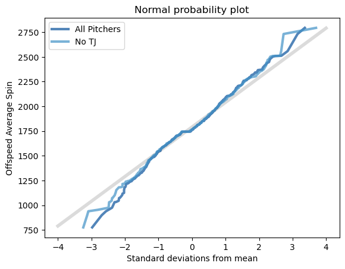

```python
# Plot Offspeed Spin and Offspeed spin without TJ against a normal distribution and evaluate fit.

mean, var = thinkstats2.TrimmedMeanVar(of_spin, p=0.01)
std = np.sqrt(var)

xs = [-4, 4]
fxs, fys = thinkstats2.FitLine(xs, mean, std)
thinkplot.Plot(fxs, fys, linewidth=4, color="0.8")

thinkplot.PrePlot(2)
xs, ys = thinkstats2.NormalProbability(of_spin)
thinkplot.Plot(xs, ys, label="All Pitchers")

xs, ys = thinkstats2.NormalProbability(of_spin_no_tj)
thinkplot.Plot(xs, ys, label="No TJ")
thinkplot.Config(
    title="Normal probability plot",
    xlabel="Standard deviations from mean",
    ylabel="Offspeed Average Spin",
)
```

### Analysis:

[output not shown]

## Create two scatter plots comparing two variables and provide your analysis on correlation and causation. Remember, covariance, Pearson’s correlation, and Non-Linear Relationships should also be considered during your analysis (Chapter 7).

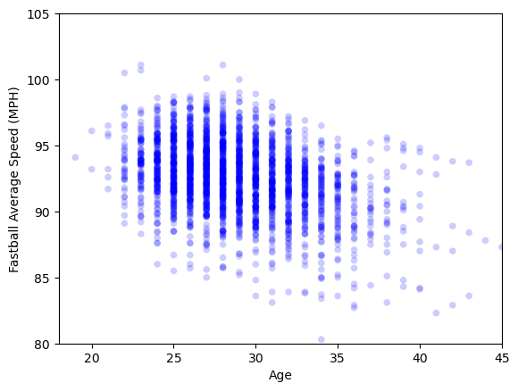

```python
# Build Scatter Plot to show relationship between age and Average Fastball Velocity.

#Use tj_data_narrow dataset to include every season of recorded data, we are no longer looking in the scope of per pitcher.

#Plot
thinkplot.Scatter(tj_data_narrow.age, tj_data_narrow.fastball_avg_speed)
thinkplot.Show(xlabel='Age', ylabel = 'Fastball Average Speed (MPH)', axis=[18,45,80,105])
```

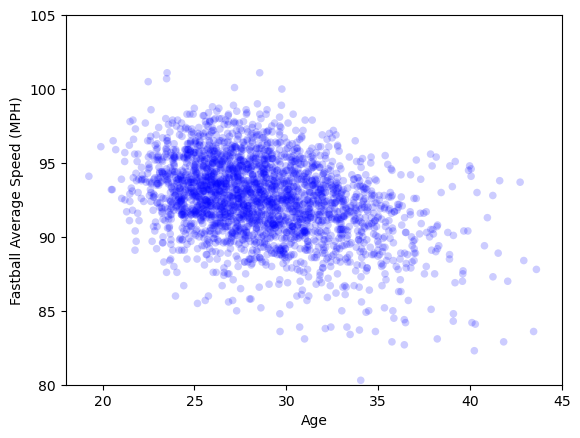

```python
# Lets Jitter to account for age only being recorded in year.

#Create Jitter variable
# Jitter by .5 of half year.
tj_age_jitter = thinkstats2.Jitter(tj_data_narrow.age, 0.5)

# Plot Jitter
thinkplot.Scatter(tj_age_jitter, tj_data_narrow.fastball_avg_speed)
thinkplot.Show(xlabel='Age', ylabel = 'Fastball Average Speed (MPH)', axis=[18,45,80,105])
```

```python
# Build Covariance function.

def Cov(xs, ys, meanx=None, meany=None):
    xs = np.asarray(xs)
    ys = np.asarray(ys)

    if meanx is None:
        meanx = np.mean(xs)
    if meany is None:
        meany = np.mean(ys)

    cov = np.dot(xs-meanx, ys-meany) / len(xs)
    return cov
```

```python
# Build Pearson Correlation

def Corr(xs, ys):
    xs = np.asarray(xs)
    ys = np.asarray(ys)

    meanx, varx = thinkstats2.MeanVar(xs)
    meany, vary = thinkstats2.MeanVar(ys)

    corr = Cov(xs, ys, meanx, meany) / np.sqrt(varx * vary)
    return corr
```

```python
# Build Spearman Correlation Function.

def SpearmanCorr(xs, ys):
    xs = pd.Series(xs)
    ys = pd.Series(ys)
    return xs.corr(ys, method='spearman')
```

```python
# Evaluate relationship between age and average fastball velocity using covariance, pearson correlation and spearman correlation.

#Print Header
print('Relationship: Age v. Fastball Average Speed (MPH)')

#Covariance
cov = Cov(tj_data_narrow.age, tj_data_narrow.fastball_avg_speed)
print('Covariance: ', cov)

#Pearson Corelation
pcor = Corr(tj_data_narrow.age, tj_data_narrow.fastball_avg_speed)
print('Pearson Correlation: ', pcor)

#Spearman Corelation
scor = SpearmanCorr(tj_data_narrow.age, tj_data_narrow.fastball_avg_speed)
print('Spearman Correlation: ', scor)
```

```
Relationship: Age v. Fastball Average Speed (MPH)
Covariance:  -3.6592835172610325
Pearson Correlation:  -0.3618083497275132
Spearman Correlation:  -0.3243521419377918
```

### Analysis

```
    As we can see above there is evidence of a correlation between increasing age and decreasing fastball velocity. It is important to know however that correlation is not equal to causation. Simply because a pitcher is a year older does not mean he will throw slower. Additionally, we see that our Pearson correlation is to a stronger degree than our spearman ran correlation, suggesting that there is a negative linear relationship between age and average fastball velocity. A baseball general manager may use this information and determine it is likely that as a pitcher they acquire ages they will become less effective over time.
```

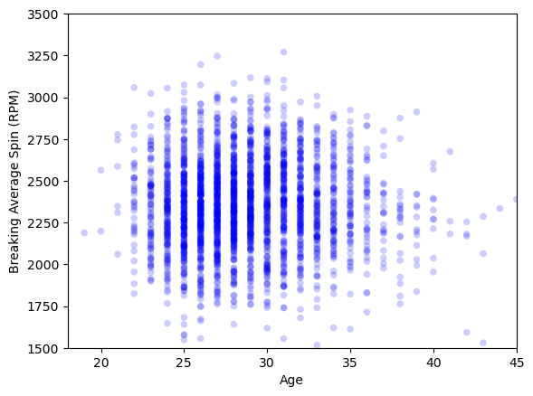

```python
# Build Scatter Plot to show relationship between age and Average Breaking Spin.

#Use tj_data_narrow dataset to include every season of recorded data, we are no longer looking in the scope of per pitcher.

#Plot
thinkplot.Scatter(tj_data_narrow.age, tj_data_narrow.breaking_avg_spin)
thinkplot.Show(xlabel='Age', ylabel = 'Breaking Average Spin (RPM)', axis=[18,45,1500,3500])
```

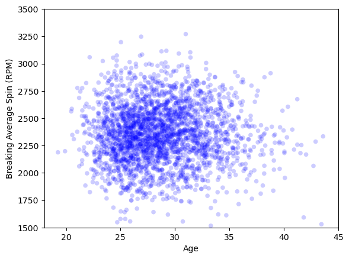

```python
# Lets Jitter to account for age only being recorded in year.

#Plot Jitter
thinkplot.Scatter(tj_age_jitter, tj_data_narrow.breaking_avg_spin)
thinkplot.Show(xlabel='Age', ylabel = 'Breaking Average Spin (RPM)', axis=[18,45,1500,3500])
```

```python
# Evaluate relationship between age and average breaking spin using covariance, pearson correlation and spearman correlation.

#Print Header
print('Relationship: Age v. Breaking Average Spin (RPM)')

#Covariance
cov = Cov(tj_data_narrow.age, tj_data_narrow.breaking_avg_spin)
print('Covariance: ', cov)

#Pearson Corelation
pcor = Corr(tj_data_narrow.age, tj_data_narrow.breaking_avg_spin)
print('Pearson Correlation: ', pcor)

#Spearman Corelation
scor = SpearmanCorr(tj_data_narrow.age, tj_data_narrow.breaking_avg_spin)
print('Spearman Correlation: ', scor)
```

```
Relationship: Age v. Breaking Average Spin (RPM)
Covariance:  -14.005230440345409
Pearson Correlation:  -0.013639160425023151
Spearman Correlation:  0.018480476695606356
```

### Analysis

[output not shown]

## Conduct a test on your hypothesis using one of the methods covered in Chapter 9.

```
    For this part of the analysis, let's dig further into some of the trends we saw earlier in the exploratory data analysis. Let's perform a series of difference of mean permutation tests to test if there is a statistical difference in the pitch stats (spin and speed) between pitchers who have and have not had Tommy John surgery.
```

```python
# Print Means.

#Print Means
print("No TJ Mean: ", no_tj.offspeed_avg_spin.mean())
print("Had TJ Mean: ",had_tj.offspeed_avg_spin.mean())
```

```
No TJ Mean:  1788.7900284387267
Had TJ Mean:  1909.435721544716
```

```python
# build a class to test the difference of means via permutation.
class DiffMeansPermute(thinkstats2.HypothesisTest):

    # Test statistic is absolut dif of means
    def TestStatistic(self, data):
        group1, group2 = data
        test_stat = abs(group1.mean() - group2.mean())
        return test_stat

    # Record sizes of groups n & m and combine them to one array
    def MakeModel(self):
        group1, group2 = self.data
        self.n, self.m = len(group1), len(group2)
        self.pool = np.hstack((group1, group2))

    # Simulate null hypothesis by shuffling pooled values into 2 groups.
    def RunModel(self):
        np.random.shuffle(self.pool)
        data = self.pool[:self.n], self.pool[self.n:]
        return data
```

```python
# Define Data (means to test)

data = had_tj.offspeed_avg_spin.values, no_tj.offspeed_avg_spin.values
```

```python
# Run Difference of means permutation hypothesis test
ht = DiffMeansPermute(data)

# Assign P-Value
pvalue = ht.PValue()

# print
print('Difference of Means by Permutation Two-Sided: ' , pvalue)
```

```
Difference of Means by Permutation Two-Sided:  0.125
```

Here's the distrubution of the test statistic (the difference in means) over many simulated samples:

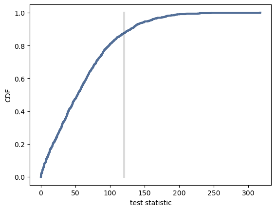

```python
# plot
ht.PlotCdf()
thinkplot.Config(xlabel='test statistic',
                   ylabel='CDF')
```

```python
class DiffMeansOneSided(DiffMeansPermute):

    def TestStatistic(self, data):
        group1, group2 = data
        test_stat = group1.mean() - group2.mean()
        return test_stat
```

[output not shown]

```python
# Run one sided hypothesis test.
ht = DiffMeansOneSided(data)

# Assign P-Value.
pvalue = ht.PValue()

#Print:
print('Difference of Means One-Sided Test P-Value: ', pvalue)
```

```
Difference of Means One-Sided Test P-Value:  0.058
```

## Analysis

[output not shown]

## For this project, conduct a regression analysis on either one dependent and one explanatory variable, or multiple explanatory variables (Chapter 10 & 11).

```
    Let's perform a logistic or poisson regression to build a mode to help predict whether or not a player will or has undergone Tommy John surgery. This model will be helpful in Major League general managers avoiding signing pitchers that are likely to become injured and need surgery.
```

Lets begin by doing some data mining to find which variable explain the most variance in Tommy John Surgerys.

```python
# Import package
import patsy
import statsmodels.formula.api as smf

# Build function to test variables  and return their rsquared

# Imput is df
def GoMining(df):
    """Searches for variables that predict pregnancy length.

    df: DataFrame of pitcher stats

    returns: list of (rsquared, variable name) pairs
    """
    variables = []
    for name in df.columns:
        try:
            #Test for variability
            if df[name].var() < 1e-7:
                continue
            # Add variable to equation predicting Tommy John (tj_history)
            formula = 'tj_history ~ ' + name
            model = smf.logit(formula, data=df)
            #if model.nobs < len(df)/2:
            #   continue

            results = model.fit()
        except (ValueError, TypeError, patsy.PatsyError) as e:
            continue
        #Add variables to list allong with their accociated psuedo r squared.
        variables.append((results.prsquared, name))

    return variables
```

```python
# Use GoMining to find fariables for logistic regression.
#Define variables, use tj_data_summary
# We want to analyse by pitcher not by every potcher season.
variables = GoMining(tj_data_summary)
# Display variables
variables
```

```
[(0.000816738841734832, 'age'),
 (6.124659554818113e-05, 'innings_pitched'),
 (0.008065127841347497, 'fastball_avg_speed'),
 (0.006600473720986488, 'fastball_avg_spin'),
 (9.379835500755718e-05, 'breaking_avg_speed'),
 (0.00012405202008936023, 'breaking_avg_spin'),
 (0.011147371242542725, 'offspeed_avg_speed'),
 (0.018064658680959744, 'offspeed_avg_spin')]
```

Looking at the results above none of our variables explain much of the variability in our data. However, In order to build our model lets start with the highest pseudo r-squared values of offspeed_avg_speed and offspeed_avg_spin.

```python
# Build Model and Summarise

model = smf.logit('tj_history ~ offspeed_avg_speed + offspeed_avg_spin', data=tj_data_summary)
results = model.fit()
results.summary()
```

```
Optimization terminated successfully.
         Current function value: 0.063807
         Iterations 9
```

Logit Regression Results

| Dep. Variable: | tj_history | No. Observations: | 994 |
| --- | --- | --- | --- |
| Model: | Logit | Df Residuals: | 991 |
| Method: | MLE | Df Model: | 2 |
| Date: | Tue, 06 Aug 2024 | Pseudo R-squ.: | 0.02318 |
| Time: | 21:52:42 | Log-Likelihood: | -63.424 |
| converged: | True | LL-Null: | -64.929 |
| Covariance Type: | nonrobust | LLR p-value: | 0.2220 |

|  | coef | std err | z | P>\|z\| | [0.025 | 0.975] |
| --- | --- | --- | --- | --- | --- | --- |
| Intercept | -14.3382 | 8.889 | -1.613 | 0.107 | -31.759 | 3.083 |
| offspeed_avg_speed | 0.0855 | 0.107 | 0.802 | 0.423 | -0.123 | 0.294 |
| offspeed_avg_spin | 0.0014 | 0.001 | 1.263 | 0.206 | -0.001 | 0.004 |

```python
# Calculate the accuracy of the model.

# Define inputs
actual = tj_data_summary['tj_history']
predict = (results.predict() >= .5)
# calculate true positive and negative
true_pos = predict * actual
true_neg  = (1-predict) * (1-actual)
# calculate accuracy.
acc = (sum(true_pos) + sum(true_neg)) / len(actual)
#print
print('Model Accuracy: ', acc)
```

```
Model Accuracy:  0.9879275653923542
```

```python
# Build model with all variables (except tj_summary) and summarize.

model = smf.logit('tj_history ~ offspeed_avg_speed + offspeed_avg_spin + breaking_avg_spin + breaking_avg_speed + fastball_avg_spin + fastball_avg_speed + innings_pitched + age', data=tj_data_summary)
results = model.fit()
results.summary()
```

```
Optimization terminated successfully.
         Current function value: 0.062765
         Iterations 9
```

Logit Regression Results

| Dep. Variable: | tj_history | No. Observations: | 994 |
| --- | --- | --- | --- |
| Model: | Logit | Df Residuals: | 985 |
| Method: | MLE | Df Model: | 8 |
| Date: | Tue, 06 Aug 2024 | Pseudo R-squ.: | 0.03913 |
| Time: | 21:52:42 | Log-Likelihood: | -62.389 |
| converged: | True | LL-Null: | -64.929 |
| Covariance Type: | nonrobust | LLR p-value: | 0.7489 |

|  | coef | std err | z | P>\|z\| | [0.025 | 0.975] |
| --- | --- | --- | --- | --- | --- | --- |
| Intercept | -15.7003 | 11.737 | -1.338 | 0.181 | -38.705 | 7.304 |
| offspeed_avg_speed | 0.0901 | 0.147 | 0.611 | 0.541 | -0.199 | 0.379 |
| offspeed_avg_spin | 0.0015 | 0.001 | 1.286 | 0.199 | -0.001 | 0.004 |
| breaking_avg_spin | -0.0009 | 0.001 | -0.751 | 0.452 | -0.003 | 0.001 |
| breaking_avg_speed | -0.1382 | 0.110 | -1.252 | 0.211 | -0.354 | 0.078 |
| fastball_avg_spin | 0.0010 | 0.002 | 0.416 | 0.678 | -0.004 | 0.005 |
| fastball_avg_speed | 0.1344 | 0.188 | 0.713 | 0.476 | -0.235 | 0.504 |
| innings_pitched | -0.0007 | 0.006 | -0.131 | 0.896 | -0.012 | 0.010 |
| age | -0.0080 | 0.084 | -0.095 | 0.924 | -0.172 | 0.156 |

```python
# Calculate the accuracy of the model.

# Define inputs
actual = tj_data_summary['tj_history']
predict = (results.predict() >= .5)
# calculate true positive and negative
true_pos = predict * actual
true_neg  = (1-predict) * (1-actual)
# calculate accuracy.
acc = (sum(true_pos) + sum(true_neg)) / len(actual)
#print
print('Model Accuracy: ', acc)
```

```
Model Accuracy:  0.9879275653923542
```

Evaluating the p-values of the different predictors, breaking average speed and offspeed average spin have the lowest p-values. neither are statistically significant, however lets build a model with them and evaluate the results.

```python
# Build Model with offspeed_avg_spin + breaking_avg_speed.

model = smf.logit('tj_history ~ offspeed_avg_spin + breaking_avg_speed', data=tj_data_summary)
results = model.fit()
results.summary()
```

```
Optimization terminated successfully.
         Current function value: 0.064092
         Iterations 9
```

Logit Regression Results

| Dep. Variable: | tj_history | No. Observations: | 994 |
| --- | --- | --- | --- |
| Model: | Logit | Df Residuals: | 991 |
| Method: | MLE | Df Model: | 2 |
| Date: | Tue, 06 Aug 2024 | Pseudo R-squ.: | 0.01881 |
| Time: | 21:52:42 | Log-Likelihood: | -63.708 |
| converged: | True | LL-Null: | -64.929 |
| Covariance Type: | nonrobust | LLR p-value: | 0.2948 |

|  | coef | std err | z | P>\|z\| | [0.025 | 0.975] |
| --- | --- | --- | --- | --- | --- | --- |
| Intercept | -5.3940 | 6.740 | -0.800 | 0.424 | -18.603 | 7.815 |
| offspeed_avg_spin | 0.0017 | 0.001 | 1.572 | 0.116 | -0.000 | 0.004 |
| breaking_avg_speed | -0.0255 | 0.081 | -0.314 | 0.754 | -0.185 | 0.134 |

```python
# Calculate the accuracy of the model.

# Define inputs
actual = tj_data_summary['tj_history']
predict = (results.predict() >= .5)
# calculate true positive and negative
true_pos = predict * actual
true_neg  = (1-predict) * (1-actual)
# calculate accuracy.
acc = (sum(true_pos) + sum(true_neg)) / len(actual)
#print
print('Model Accuracy: ', acc)
```

```
Model Accuracy:  0.9879275653923542
```

```python
# Build Model with just offspeed spin

model = smf.logit('tj_history ~ offspeed_avg_spin', data=tj_data_summary)
results = model.fit()
results.summary()
```

```
Optimization terminated successfully.
         Current function value: 0.064141
         Iterations 9
```

Logit Regression Results

| Dep. Variable: | tj_history | No. Observations: | 994 |
| --- | --- | --- | --- |
| Model: | Logit | Df Residuals: | 992 |
| Method: | MLE | Df Model: | 1 |
| Date: | Tue, 06 Aug 2024 | Pseudo R-squ.: | 0.01806 |
| Time: | 21:52:42 | Log-Likelihood: | -63.756 |
| converged: | True | LL-Null: | -64.929 |
| Covariance Type: | nonrobust | LLR p-value: | 0.1256 |

|  | coef | std err | z | P>\|z\| | [0.025 | 0.975] |
| --- | --- | --- | --- | --- | --- | --- |
| Intercept | -7.4168 | 2.031 | -3.651 | 0.000 | -11.398 | -3.435 |
| offspeed_avg_spin | 0.0016 | 0.001 | 1.546 | 0.122 | -0.000 | 0.004 |

```python
# Calculate the accuracy of the model.

# Define inputs
actual = tj_data_summary['tj_history']
predict = (results.predict() >= .5)
# calculate true positive and negative
true_pos = predict * actual
true_neg  = (1-predict) * (1-actual)
# calculate accuracy.
acc = (sum(true_pos) + sum(true_neg)) / len(actual)
#print
print('Model Accuracy: ', acc)
```

```
Model Accuracy:  0.9879275653923542
```

## Analysis

```
   After comparing all the models above none of the variables in our dataset is a statistically significant predictor of a pitcher needing Tommy John surgery. However, some of the models do provide a greater pseudo r-squared value meaning that they predict more of the variance that we see in the tj_history variable. Naturally the model with all variables produces the highest r-squared. All models produce the same accuracy though, given this one should chose the simplest model which is the model using only offspeed average spin as a variable. offspeed average spin is also the variable closest to statistical significance. In practice an MLB general manager could use this model to predict it a pitcher would require Tommy John surgery; however, I would be skeptical of the effectiveness of the model.
```

# Summary

[output not shown]

# Works Cited

Simon, J. M. (2020, May 13). Let’s model! using random forest to predict UCL reconstruction. Medium. https://medium.com/analytics-vidhya/lets-model-using-random-forest-to-predict-ucl-reconstruction-6185ebdc853e

```python
tj_data_summary.to_csv('tj_summary.csv', index=False)
```